# Analyzing Statistics Canada’s Survey Microdata: A Primer using R

Author

Mayur Matang

Published

November 1, 2026

## About this blog

Statistics Canada runs some of the richest household surveys in the country, and it releases the underlying microdata - the individual, anonymized survey responses - for public use. Most people never touch these files. They rely instead on the summary tables Statistics Canada publishes. Those tables are useful, but they only show a fraction of what the data can answer. The moment your data isn’t in a pre-made table, you’re stuck, unless you can work with the microdata yourself.

This blog is a walkthrough of doing exactly that. Moreover, it is made for practitioners - so that you analyze the survey data and get the estimates without delving much into the survey theory.

## Pathway

- **Part 0:** **Introduction -** What is this blog about?
- **Part 1: Downloading Statistics Canada Microdata -** What a public use microdata file is and how to access it.
- **Part 2: Inside the Downloaded Folder -** To understand what all survey docs are provided and what are they for.
- **Part 3: Setting Up R -** The code to load the survey microdata and to set up the survey design object needed for analysis.
- **Part 4: Replicate a Statistics Canada Table -** Produce the exact estimates with correct confidence intervals to check if the method is sound.
- **Part 5: Some More Analysis** - More code for descriptive analysis, that can help you answer any of your question from the survey data.
- **Part 6: Hypothesis Testing** - Define null hypothesis and alternate hypothesis to find which to reject.
- **Part 7: Modeling Data** - Develop anova and regression models.

**Blog objective**: To hand you the ability to get answers straight from the survey microdata, without relying on Statistics Canada to publish their table/analysis, which may never be published.

## Before you start

This document assumes a little groundwork, though not much. You’ll get the most out of it if you have:

- **Basic coding in R** - you can install and load packages, run a script, and read codes written with the pipe (|>). You don’t need to be fluent; if you can follow along and modify code, that’s enough.
- **Some knowledge of surveys** - a working sense of what a sample, a weight, and a confidence interval are. You don’t need formal training in sampling theory.
- **Access to the survey microdata** - To download the data from the official Statistics Canada website: https://www150.statcan.gc.ca/n1/pub/56m0003x/2020001/2022.zip

## Here we go.

### A. Load packages

If you get an error, you might need to install one or more of these packages

```r
library(here)
library(memisc)
library(dplyr)
library(srvyr)
library(survey)
library(ggplot2)
```

### B. Import Data

Statistics Canada generally provides csv, txt, sas and all kinds of data files. But try importing SAS/SPSS/STATA files because they may contain labelled columns. Labelled columns give a short description of the column. Else use the .sps layout files under spss folder.

For this survey, we are provided .txt and .sas7bdat data files. Im using .txt data file because .sas7bdat file lacks label data.

```r
# import and create the file with variable names and labels using memisc package
# Only the 5 files below are needed, rest can be deleted
cius <-
  spss.fixed.file(here("raw-data", "CIUS_PUMF.txt"),            # main data file
    columns.file = here("raw-data", "CIUS_PUMF_i.sps"),         # separate data into columns
    varlab.file  = here("raw-data", "CIUS_PUMF_vare.sps"),      # labels of variables
    codes.file   = here("raw-data", "CIUS_PUMF_vale.sps"),      # labels of responses
    missval.file = here("raw-data", "CIUS_PUMF_miss.sps")       # missing values file
  )
```

```
Warning: 5 variables have duplicated labels:
  AC_010A, AC_020A, AC_030A, AC_060A, ONL_SHOP
```

The data is extracted but we get this warning of duplicated labels. This is because Statistics Canada has ‘Dont know’ response twice in these variables <AC_010A, AC_020A, AC_030A, AC_060A, ONL_SHOP>. You can check the codebook and search for one of these variables.

```r
data_set <- as.data.set(cius)     # Create memisc object that can be converted to data frame
# description(data_set$AC_010A)   # This function lists the variable with its description
# codebook(data_set$AC_010A)      # This function shows codes, labels, and missing values

# Set dbl vars so that the next step (as.data.frame) converts the rest to factors and keeps these numeric
num_vars <- c("PUMFID",
              "EC_G011A", "EC_G011B", "EC_G011C", "EC_G011D",
              "EC_G011E", "EC_G011F", "EC_G011X",
              "EC_G012A", "EC_G013A", "EC_G014A",
              "SUM_GTOT", "WTPG",
              paste0("WRPG", 1:1000))

measurement(data_set) <- list(interval = num_vars)

df <- as.data.frame(data_set)  # this creates the data frame with labels
```

### C. Explore Dataset

Surveys are huge in size. The Canadian Internet Use Survey, 2022 has 25118 observations (surveyed persons) and 1342 variables (columns) about each of them. The code below gives a glimpse of the first 10 variables and some of their data points.

Opening the file in viewer (view similar to ms excel) is another way to get a feel of the dataset. Just click on df under the environment panel. You will see plenty of NA in columns. These are valid skip, dont know, refusal, and not stated responses.

```r
df |>
  select(1:5)  |>   # change numbers to explore more variables
  glimpse()
```

```
Rows: 25,118
Columns: 5
$ PUMFID   <dbl> 100000, 100001, 100002, 100003, 100004, 100005, 100006, 10000…
$ PROVINCE <fct> Ontario, Quebec, Manitoba, British Columbia, Quebec, Saskatch…
$ LUC_RST  <fct> Larger Urban Centres (CMA/CA), Larger Urban Centres (CMA/CA),…
$ RRS_G12  <fct> One person household, Two person household, Five or more pers…
$ AGE_GRP  <fct> 65 years and over, 35 to 44 years, 15 to 24 years, 65 years a…
```

```r
# change select to '1:341' and you will see all the variables of the survey
# change select to '342:1342' and you will see all the weight variables
```

Had we used the sas7bdat file, we would have only seen numbers instead of the labels. For example, under Gender variable, we would have seen zeros and ones, not male and female.

### D. Survey Design

The design object essentially helps R know about the survey methodology used. The code below can mostly be used for all the Statistics Canada surveys.

Sometimes the bootstrap weight columns are provided in a separate file that needs to be joined with the main data file. For this survey, we have been given everything in one file. The last 1000 variables are all bootstrap weights: WRPG1…WRPG1000.

Note: If a separate file is provided, ensure that the number of rows in both the files are the same. Stats Can has goofed up with many datasets where the bootstrap file has lesser rows. You can write to the coordinator of the survey if you face this issue. I have and I’m not sure when they will fix it. It is the govt after all :P

```r
design <- df %>%
  as_survey_rep(
    weights          = WTPG,           # Weight column
    repweights       = WRPG1:WRPG1000, # Bootstrap weight columns in the dataset
    type             = "bootstrap",
    mse              = TRUE
  )
```

For all analysis henceforth, we will be using this ‘design’ object.

### E. Match results with Statistics Canada

Statistics Canada [Table: 22-10-0134-01](https://www150.statcan.gc.ca/t1/tbl1/en/cv!recreate.action?pid=2210013401&selectedNodeIds=&checkedLevels=0D1,0D2,1D1&refPeriods=20220101,20220101&dimensionLayouts=layout3,layout2,layout2&vectorDisplay=false): Access to the Internet at home by geography

#### E.1 Access to home internet at national level

Variable AC_030A captures yes/no responses whether home internet is available.

```r
home_internet_canada <- design %>%
  filter(AC_030A %in% c("Yes", "No")) %>% #Keep only yes/no responses whether home internet available
  group_by(AC_030A) %>%
  summarize(p = survey_prop(vartype = c("ci", "cv")), N = unweighted(n()))

home_internet_canada
```

| AC_030A | p | p_low | p_upp | p_cv | N |
| --- | --- | --- | --- | --- | --- |
| Yes | 0.9400992 | 0.93663534 | 0.94338515 | 0.001816544 | 23366 |
| No | 0.0599008 | 0.05661485 | 0.06336466 | 0.028509320 | 1700 |

Nationally, 94% of population has internet at home. (The estimate and its confidence intervals match with the table)

**Abbreviations**:  
low: lower confidence interval; upp: upper confidence interval; CV: coefficient of variation; N: sample size; SE: standard error.

I’ve included CV and N here to assess the quality of the estimates. Estimate Quality is —  
Acceptable: N >= 15 and CV <= 0.165  
Marginal: N >= 15 and CV 0.166-0.333 (Caution!)  
Unacceptable: N < 15 or CV > 0.333 (Caution!!!)

#### E.2 Access to home internet at census metropolitan areas (cma) and outside of it

```r
home_internet_cma <- design %>%
  filter(AC_030A %in% c("Yes", "No")) %>% #Keep only yes/no responses whether home internet available
  group_by(LUC_RST, AC_030A) %>%
  summarize(p = survey_prop(vartype = c("ci","cv")), N = unweighted(n())) |>
  filter(AC_030A == "Yes")             # 1 = yes, access to home internet

home_internet_cma
```

| LUC_RST | AC_030A | p | p_low | p_upp | p_cv | N |
| --- | --- | --- | --- | --- | --- | --- |
| Larger Urban Centres (CMA/CA) | Yes | 0.9499299 | 0.9463057 | 0.9533215 | 0.001863557 | 17399 |
| Rural and Small Town (non-CMA/CA) | Yes | 0.8864086 | 0.8752804 | 0.8966612 | 0.006114913 | 4994 |
| Prince Edward Island | Yes | 0.9223018 | 0.9002223 | 0.9398220 | 0.010695806 | 973 |

94.99% of urban and 88.6% of rural population has internet at home. (Urban/Rural estimates and their confidence intervals match with the statistics canada table)

#### E.3 Access to home internet at provincial level

```r
home_internet_province <- design %>%
  filter(AC_030A %in% c("Yes", "No")) %>% # Keep only yes/no responses
  group_by(PROVINCE, AC_030A) %>%
  summarize(p = survey_prop(vartype = c("ci", "cv")), N = unweighted(n())) |>
  filter(AC_030A == "Yes")             # 1 = yes, access to home internet

home_internet_province
```

| PROVINCE | AC_030A | p | p_low | p_upp | p_cv | N |
| --- | --- | --- | --- | --- | --- | --- |
| Newfoundland and Labrador | Yes | 0.9414033 | 0.9259888 | 0.9537677 | 0.007346777 | 1122 |
| Prince Edward Island | Yes | 0.9223018 | 0.9002223 | 0.9398220 | 0.010695806 | 973 |
| Nova Scotia | Yes | 0.9042636 | 0.8836046 | 0.9215814 | 0.010524460 | 1184 |
| New Brunswick | Yes | 0.9269624 | 0.9088665 | 0.9416955 | 0.008869857 | 928 |
| Quebec | Yes | 0.9150228 | 0.9069055 | 0.9224928 | 0.004312499 | 5192 |
| Ontario | Yes | 0.9481429 | 0.9417770 | 0.9538470 | 0.003221356 | 6121 |
| Manitoba | Yes | 0.9060425 | 0.8861517 | 0.9227611 | 0.010191767 | 1327 |
| Saskatchewan | Yes | 0.9152308 | 0.8964723 | 0.9308525 | 0.009442473 | 1391 |
| Alberta | Yes | 0.9572998 | 0.9479751 | 0.9650149 | 0.004466769 | 1898 |
| British Columbia | Yes | 0.9663207 | 0.9589644 | 0.9723962 | 0.003471175 | 3230 |

Voila! The results above match the estimates in the Statistics Canada table.

As per the survey user guide, estimates with N >= 15 & CV in the range 0% - 16.5% are acceptable and no warning is required while publishing them. In this section, all estimates of having home internet have N >> 15 & CV << 16.5%, giving them the ‘A’ superscript in the Statistics Canada table.

### F. Descriptive Analysis

#### F.1 Count: Population estimate of non-institutionalized 15+ yr olds (excl. 3 northern territories & reserves)

```r
design %>%
  survey_count(name = "pop", vartype = c("se", "ci", "cv"))
```

| pop | pop_se | pop_low | pop_upp | pop_cv |
| --- | --- | --- | --- | --- |
| 32612697 | 4.14083e-07 | 32612697 | 32612697 | 1.269699e-14 |

Population estimate is 32.6M persons. The population intervals are the same because the weights are fixed to the population.

#### F.2 Count: Population in 10 provinces

```r
design %>%
  survey_count(PROVINCE, name = "pop", vartype = c("ci", "se"))
```

| PROVINCE | pop | pop_low | pop_upp | pop_se |
| --- | --- | --- | --- | --- |
| Newfoundland and Labrador | 455669 | 455669 | 455669 | 3.245720e-08 |
| Prince Edward Island | 143193 | 143193 | 143193 | 2.694047e-08 |
| Nova Scotia | 871295 | 871295 | 871295 | 5.426484e-08 |
| New Brunswick | 688478 | 688478 | 688478 | 2.238788e-08 |
| Quebec | 7276993 | 7276993 | 7276993 | 7.404890e-08 |
| Ontario | 12767360 | 12767360 | 12767360 | 1.293567e-07 |
| Manitoba | 1133043 | 1133043 | 1133043 | 4.613448e-08 |
| Saskatchewan | 960786 | 960786 | 960786 | 4.745829e-08 |
| Alberta | 3756246 | 3756246 | 3756246 | 4.257043e-08 |
| British Columbia | 4559634 | 4559634 | 4559634 | 4.751247e-08 |

Ontario’s population estimate is 12.7M persons. (Remember the population is 15+ yr old non-institutionalized persons in Canada except the 3 northern territories and reserves)

#### F.3 Count: Population in census metropolitan areas and outside

```r
design %>%
  survey_count(LUC_RST,
               vartype = c("se", "ci", "cv"), name = "pop")
```

| LUC_RST | pop | pop_se | pop_low | pop_upp | pop_cv |
| --- | --- | --- | --- | --- | --- |
| Larger Urban Centres (CMA/CA) | 27482983 | 1.217995e+04 | 27459082 | 27506884 | 4.431816e-04 |
| Rural and Small Town (non-CMA/CA) | 4986521 | 1.217995e+04 | 4962620 | 5010422 | 2.442575e-03 |
| Prince Edward Island | 143193 | 2.694047e-08 | 143193 | 143193 | 1.881410e-13 |

Urban population estimate is 27.48M [27.45M, 27.5M].

#### F.4 Count: Population in provinces & census metropolitan areas

```r
design |>
  survey_count(PROVINCE, LUC_RST, name = "pop")
```

| PROVINCE | LUC_RST | pop | pop_se |
| --- | --- | --- | --- |
| Newfoundland and Labrador | Larger Urban Centres (CMA/CA) | 250064.0 | 3.305954e-08 |
| Newfoundland and Labrador | Rural and Small Town (non-CMA/CA) | 205605.0 | 1.304832e-08 |
| Prince Edward Island | Prince Edward Island | 143193.0 | 2.694047e-08 |
| Nova Scotia | Larger Urban Centres (CMA/CA) | 587155.0 | 2.023289e-08 |
| Nova Scotia | Rural and Small Town (non-CMA/CA) | 284140.0 | 3.894892e-08 |
| New Brunswick | Larger Urban Centres (CMA/CA) | 443007.0 | 1.175037e-08 |
| New Brunswick | Rural and Small Town (non-CMA/CA) | 245471.0 | 2.512913e-08 |
| Quebec | Larger Urban Centres (CMA/CA) | 5965629.0 | 9.014811e+03 |
| Quebec | Rural and Small Town (non-CMA/CA) | 1311364.0 | 9.014811e+03 |
| Ontario | Larger Urban Centres (CMA/CA) | 11545359.5 | 3.733906e+03 |

[output cut: 9 more lines]

Ontario has 11.5m population estimate in urban & 1.2m in rural.

#### F.5 Total: How much total amount was spent on music/video downloads or streaming subscriptions in past 12 months?

Variable EC_G011A captures the amount spent. Use the codebook to learn more about the variable.

```r
design  |>
  summarize(amt_spent = survey_total(EC_G011A, vartype = c("ci", "se"), na.rm = T))
```

| amt_spent | amt_spent_low | amt_spent_upp | amt_spent_se |
| --- | --- | --- | --- |
| 2241805470 | 2152710878 | 2330900063 | 45402186 |

Nationally, the total amount spent is 2.24B [2.15B , 2.33B] with se 45.4M.

#### F.6 Total: Amount spent by province

```r
design |>
  group_by(PROVINCE) |>
  summarize(amt_spent = survey_total(EC_G011A, vartype = c("ci", "se"), na.rm = T))
```

| PROVINCE | amt_spent | amt_spent_low | amt_spent_upp | amt_spent_se |
| --- | --- | --- | --- | --- |
| Newfoundland and Labrador | 29317890 | 24346014 | 34289765 | 2533644 |
| Prince Edward Island | 11111693 | 8977057 | 13246329 | 1087801 |
| Nova Scotia | 57766690 | 48243616 | 67289764 | 4852914 |
| New Brunswick | 41578690 | 33424721 | 49732659 | 4155224 |
| Quebec | 363691827 | 335528756 | 391854897 | 14351769 |
| Ontario | 978550507 | 910366755 | 1046734259 | 34746120 |
| Manitoba | 78208017 | 66747491 | 89668544 | 5840230 |
| Saskatchewan | 69785787 | 60606046 | 78965529 | 4677953 |
| Alberta | 276342653 | 243933584 | 308751722 | 16515509 |
| British Columbia | 335451716 | 303608578 | 367294853 | 16227114 |

Ontario spent $978M.

#### F.7 Total: Amount spent by gender

```r
design  |>
  group_by(GENDER) |>
  summarize(amt_spent = survey_total(EC_G011A, vartype = c("ci", "se"), na.rm = T))
```

| GENDER | amt_spent | amt_spent_low | amt_spent_upp | amt_spent_se |
| --- | --- | --- | --- | --- |
| Male | 1249905094 | 1180494822 | 1319315365 | 35371149 |
| Female | 991900376 | 936422069 | 1047378683 | 28271485 |

Male spent $1.2B & Female $991M.

#### F.8 Mean: Amount spent by a person on average on music/video downloads or streaming subscriptions

```r
design  |>
  summarize(amt_spent = survey_mean(EC_G011A, vartype = c("ci", "se"), na.rm = T))
```

| amt_spent | amt_spent_low | amt_spent_upp | amt_spent_se |
| --- | --- | --- | --- |
| 187.47 | 180.9884 | 193.9516 | 3.302991 |

On an average, a person spent $187 [181,194] with se $3.3.

#### F.9 Mean: Amount spent by a person on average on music/video downloads or streaming subscriptions by province

```r
mean_EC_G011A <- design  |>
  group_by(PROVINCE) |>
  summarize(amt_spent = survey_mean(EC_G011A, vartype = c("ci", "se"), na.rm = T))
```

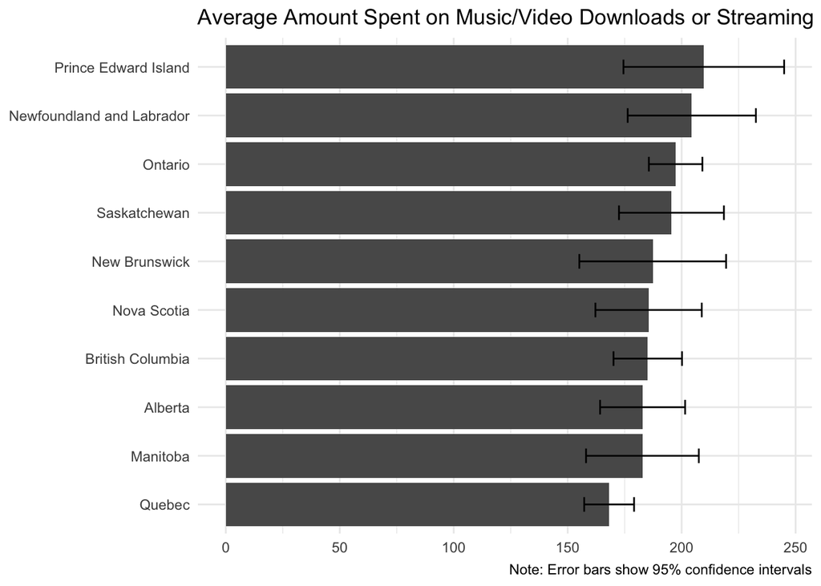

```r
mean_EC_G011A |>
  ggplot(aes(x = reorder(PROVINCE, amt_spent), y = amt_spent)) +
  geom_col() +
  geom_errorbar(aes(ymin = amt_spent_low, ymax = amt_spent_upp), width = 0.3) +
  coord_flip() +
  labs(x = NULL, y = NULL,
       title = "Average Amount Spent on Music/Video Downloads or Streaming Subscriptions",
       caption = "Note: Error bars show 95% confidence intervals") +
  theme_minimal()
```

On an average, a person in Ontario spent $197 on avg.

#### F.10 Quantile: Distribution of amount spent in quartiles

```r
design  |>
  summarize(amt_spent = survey_quantile(EC_G011A, quantiles = c(0.25, .5, 0.75), na.rm = T))
```

| amt_spent_q25 | amt_spent_q50 | amt_spent_q75 | amt_spent_q25_se | amt_spent_q50_se | amt_spent_q75_se |
| --- | --- | --- | --- | --- | --- |
| 11 | 120 | 275 | 1.273988 | 6.115144 | 12.73988 |

Median amount spent is $120 with se $6.12. The average was much higher at $187.

#### F.11 Quantile: Distribution of amount spent in quartiles by province

```r
design  |>
  group_by(PROVINCE) |>
  summarize(
    amt_spent = survey_quantile(EC_G011A, quantiles = c(0.25, .5, 0.75), na.rm = TRUE))
```

| PROVINCE | amt_spent_q25 | amt_spent_q50 | amt_spent_q75 | amt_spent_q25_se | amt_spent_q50_se | amt_spent_q75_se |
| --- | --- | --- | --- | --- | --- | --- |
| Newfoundland and Labrador | 36 | 140 | 300 | 10.165433 | 13.977470 | 38.120372 |
| Prince Edward Island | 14 | 135 | 300 | 13.468376 | 17.788421 | 40.659249 |
| Nova Scotia | 15 | 120 | 300 | 7.630045 | 25.433484 | 25.433484 |
| New Brunswick | 0 | 100 | 300 | 4.318069 | 25.400406 | 50.800811 |
| Quebec | 12 | 120 | 240 | 2.802774 | 6.115144 | 6.115144 |
| Ontario | 14 | 120 | 300 | 2.547977 | 7.643930 | 15.287859 |
| Manitoba | 10 | 100 | 254 | 5.089270 | 14.758882 | 15.267809 |
| Saskatchewan | 16 | 120 | 300 | 3.817282 | 7.634564 | 30.538258 |
| Alberta | 10 | 100 | 265 | 3.056253 | 11.206262 | 15.281267 |
| British Columbia | 10 | 120 | 250 | 4.076762 | 7.643930 | 15.287859 |

25th percentile amount spent in Ontario is $14 with se $2.55.

#### F.12 Variance & Std deviation: Amount spent

```r
design  |>
  summarize(
    amt_var = survey_var(EC_G011A, na.rm = TRUE),
    amt_sd = survey_sd(EC_G011A, na.rm = TRUE)
            )
```

| amt_var | amt_var_se | amt_sd |
| --- | --- | --- |
| 51619.21 | 1623.502 | 227.1986 |

The population variance of amount spent on music/video downloads or streaming subscriptions in past 12 months is 51619.2 and standard deviation is $227.2

#### F.13 Variance & Std deviation: Amount spent by provinces

```r
design |>
  group_by(PROVINCE) |>
  summarize(
    amt_var = survey_var(EC_G011A, na.rm = TRUE),
    amt_sd  = survey_sd(EC_G011A, na.rm = TRUE)
  )
```

| PROVINCE | amt_var | amt_var_se | amt_sd |
| --- | --- | --- | --- |
| Newfoundland and Labrador | 53493.71 | 7414.352 | 231.2871 |
| Prince Edward Island | 53305.34 | 6494.536 | 230.8795 |
| Nova Scotia | 42734.53 | 4770.633 | 206.7233 |
| New Brunswick | 51043.58 | 6987.004 | 225.9283 |
| Quebec | 39344.85 | 2471.612 | 198.3554 |
| Ontario | 56981.31 | 2969.574 | 238.7076 |
| Manitoba | 57398.72 | 6802.534 | 239.5803 |
| Saskatchewan | 59182.12 | 5425.755 | 243.2738 |
| Alberta | 50028.80 | 4507.538 | 223.6712 |
| British Columbia | 50941.96 | 3762.720 | 225.7033 |

The population variance of amount spent on music/video downloads or streaming subscriptions in past 12 months for Ontario is 56981.3 and standard deviation is $238.7

#### F.14 Correlation: Amount spent on music/video/streaming (EC_G011A) and gambling (EC_G011D)

```r
design %>%
  summarize(corr = survey_corr(EC_G011A, EC_G011D,
                               vartype = c("ci", "se"),
                               na.rm = T))
```

| corr | corr_low | corr_upp | corr_se |
| --- | --- | --- | --- |
| 0.07210157 | 0.04287839 | 0.1013248 | 0.014892 |

The correlation between amount spent on music/video/streaming & gambling indicates a weak but positive relationship. Since the confidence interval do not include zero, it is statistically significant.

#### F.15 Correlation: Amount spent on music/video/streaming (EC_G011A) and gambling (EC_G011D) by province

```r
design %>%
  group_by(PROVINCE) |>
  summarize(corr = survey_corr(EC_G011A, EC_G011D,
                               vartype = c("ci", "se"),
                               na.rm = T))
```

| PROVINCE | corr | corr_low | corr_upp | corr_se |
| --- | --- | --- | --- | --- |
| Newfoundland and Labrador | 0.04493022 | -0.0354268147 | 0.1252873 | 0.04094957 |
| Prince Edward Island | 0.19738044 | 0.0022846265 | 0.3924763 | 0.09941991 |
| Nova Scotia | 0.07563135 | -0.0358967316 | 0.1871594 | 0.05683419 |
| New Brunswick | 0.28635843 | 0.1211637897 | 0.4515531 | 0.08418107 |
| Quebec | 0.06646565 | -0.0117621634 | 0.1446935 | 0.03986453 |
| Ontario | 0.06909563 | 0.0183714326 | 0.1198198 | 0.02584881 |
| Manitoba | 0.11120600 | -0.0096805496 | 0.2320926 | 0.06160322 |
| Saskatchewan | 0.09343616 | 0.0002580167 | 0.1866143 | 0.04748315 |
| Alberta | 0.04694851 | -0.0446312072 | 0.1385282 | 0.04666860 |
| British Columbia | 0.06760258 | 0.0196040400 | 0.1156011 | 0.02445983 |

The correlation of amount spent on music/video/streaming & gambling for Ontario is 6.9%, positive but weak and statistically significant.

#### F.16 Ratio: Total amount spent (SUM_GTOT) online and on physical goods (EC_G012A)

```r
design %>%
  summarize(ratio = survey_ratio(EC_G012A, SUM_GTOT,
                               vartype = c("ci", "se"),
                               na.rm = T))
```

| ratio | ratio_low | ratio_upp | ratio_se |
| --- | --- | --- | --- |
| 0.6084448 | 0.6012942 | 0.6155953 | 0.003643875 |

For every dollar Canadians spend online, 61 cents are spent on physical goods.

#### F.17 Not Ratio: How is the above different from survey_mean(EC_G012A/SUM_GTOT) ?

```r
design %>%
  summarize(avg = survey_mean(EC_G012A/SUM_GTOT,
                                 na.rm = T))
```

| avg | avg_se |
| --- | --- |
| 0.6805731 | 0.003146023 |

An average person spends 68 cents of its online dollars to physical goods.

#### F.18 Ratio: Amount spent online (SUM_GTOT) & on physical goods (EC_G012A) by gender

```r
design %>%
  group_by(GENDER) |>
  summarize(ratio = survey_ratio(EC_G012A, SUM_GTOT,
                                 vartype = c("ci", "se"),
                                 na.rm = T))
```

| GENDER | ratio | ratio_low | ratio_upp | ratio_se |
| --- | --- | --- | --- | --- |
| Male | 0.6041592 | 0.5937819 | 0.6145365 | 0.005288215 |
| Female | 0.6128680 | 0.6028318 | 0.6229042 | 0.005114396 |

For every dollar males spend online, 60 cents are spent on physical goods.

### G. Hypothesis Testing

#### G.1 **One-sample t-test for mean**

Mean amount of spending across Canada on E-books, audio books or podcast books (EC_G011B)

```r
design  |>
  summarize(mean_amt_spent = survey_mean(EC_G011B, na.rm =T))
```

| mean_amt_spent | mean_amt_spent_se |
| --- | --- |
| 32.6691 | 1.219297 |

The mean spending on e-books in Canada is $32.7. Now lets say a newspaper reported that mean spending on E-books/audio books/podcast books is $30. To test if the newspaper is right, we can setup a hypothesis test.

Null Hypothesis: mean = 30 (newspaper is right)  
Alternate Hypothesis: mean != 30 (newspaper is not right) (!= is the ‘not equal to’ sign)

```r
ttest_1 <- design |>
  svyttest(
    formula = EC_G011B - 30 ~ 0,
    na.rm = TRUE
    ) |>
  broom::tidy()

ttest_1
```

| estimate | statistic | p.value | parameter | conf.low | conf.high | method | alternative |
| --- | --- | --- | --- | --- | --- | --- | --- |
| 2.669099 | 2.189047 | 0.02882451 | 998 | 0.2764181 | 5.06178 | Design-based one-sample t-test | two.sided |

```r
ttest_1$estimate + 30             # To obtain the estimate EC_G011B - 30
```

```
   mean
32.6691
```

The mean spending is not $30 as the newspaper proposes because the p-value is less than 0.05 and hence we reject the null hypothesis. The mean is not equal to $30, it is between 30.27-35.06 at 95% confidence interval.

#### G.2 **One-sample t-test for mean, again**

Imagine a religious body claims that there is no spending on online gambling done in Ontario. You as a researcher want to test this claim. So you set up a hypothesis test.

Null Hypothesis: mean = 0 (religious body is right)  
Alternate Hypothesis: mean != 0 (religious body is not right)

```r
ttest_2 <- design  |>
  filter(PROVINCE == "Ontario") |>  # max value for this variable is $2000, removes valid skip
  svyttest(
    formula = EC_G011D ~ 0,
    na.rm = TRUE,
  )

ttest_2
```

```
    Design-based one-sample t-test

data:  EC_G011D ~ 0
t = 6.6545, df = 998, p-value = 4.68e-11
alternative hypothesis: true mean is not equal to 0
95 percent confidence interval:
 15.10608 27.74129
sample estimates:
    mean
21.42368
```

```r
ttest_2$estimate + 0
```

```
    mean
21.42368
```

The p-value is less than 0.05, so we can reject the null hypothesis. The mean amount spent is $21.4 on online gambling in Ontario. The confidence interval at 95% is (15.1, 27.7)

```r
confint(ttest_2, level = 0.95)  # 95% confidence interval
```

```
                        2.5 %   97.5 %
as.numeric(EC_G011D) 15.10608 27.74129
attr(,"conf.level")
[1] 0.95
```

```r
confint(ttest_2, level = 0.99)  # 99% confidence interval
```

```
[1] 13.11513 29.73224
attr(,"conf.level")
[1] 0.99
```

At 99% Confidence interval, the mean is [13.1, 29.7], not containing 0. So we can conclude that this estimate is statistically different from 0.

#### G.3 **One-sample t-test for proportion**

```r
design |>
  filter(AC_010A %in% c("Yes","No")) |>  # Keep only yes/no reponses whether mobile internet available
  group_by(AC_010A) |>
  summarise(p = survey_prop())
```

```
When `proportion` is unspecified, `survey_prop()` now defaults to `proportion = TRUE`.
ℹ This should improve confidence interval coverage.
```

| AC_010A | p | p_se |
| --- | --- | --- |
| Yes | 0.8429313 | 0.002783991 |
| No | 0.1570687 | 0.002783991 |

This shows 84.3% have access to mobile internet. If we wanted to test if this differs from 80%, we can setup

Null Hypothesis: p = 0.8  
Alternate Hypothesis: p != 0.8

```r
ttest_3 <- design |>
  filter(AC_010A %in% c("Yes","No")) |>
  svyttest(
    formula = (AC_010A == "Yes") - 0.8 ~ 0,
    na.rm = TRUE
  ) |>
  broom::tidy()

ttest_3
```

| estimate | statistic | p.value | parameter | conf.low | conf.high | method | alternative |
| --- | --- | --- | --- | --- | --- | --- | --- |
| 0.04293132 | 15.42078 | 2.768442e-48 | 998 | 0.03746817 | 0.04839446 | Design-based one-sample t-test | two.sided |

```r
ttest_3$estimate + 0.8
```

```
     mean
0.8429313
```

The p-value is less than 0.05, so we can reject the null hypothesis. The proportion of population is 84.3% with mobile internet access and it is significantly different from 80%.

#### G.4 **One-sample t-test for proportion, again**

Do you have internet access at home ?  
Let us test whether proportion of people not having home internet in Canada is 0.

Null hypo: p = 0 or no person in canada who don’t have home internet  
Alternate hypo: p != 0 or there are people in canada who don’t have home internet

```r
ttest_4 <- design |>
  filter(AC_030A %in% c("Yes","No")) |> # Keep only yes/no reponses whether home internet available
  svyttest(
    formula = (AC_030A == "No") ~ 0,
    na.rm = TRUE
  ) |>
  broom::tidy()

ttest_4
```

| estimate | statistic | p.value | parameter | conf.low | conf.high | method | alternative |
| --- | --- | --- | --- | --- | --- | --- | --- |
| 0.0599008 | 35.07625 | 2.844255e-176 | 998 | 0.05654965 | 0.06325196 | Design-based one-sample t-test | two.sided |

```r
ttest_4$estimate
```

```
     mean
0.0599008
```

At alpha=0.05, p value is less than 0.05. Hence we can reject null hypothesis that there are no people in canada who don’t have home internet.

#### G.5 **Unpaired two sample t-test**

Amount spent on online purchase of physical goods (EC_G012A). Does spending by males and females differ?

Null: mean spending of men = mean spending of women  
Alternate: mean spending of men != mean spending of women

```r
ttest_5 <- design %>%
  svyttest(
    formula = EC_G012A ~ GENDER,
    na.rm = TRUE
  ) |>
  broom::tidy()

ttest_5
```

| estimate | statistic | p.value | parameter | conf.low | conf.high | method | alternative |
| --- | --- | --- | --- | --- | --- | --- | --- |
| -59.9126 | -1.766218 | 0.07766495 | 998 | -126.4781 | 6.652861 | Design-based t-test | two.sided |

There is a difference in mean spending but it is not statistically significant as p > 0.05. Hence null hypothesis cannot be rejected.

#### G.6 **Paired two sample t-test**

Are people spending more on e-books (EC_G011B) or online news (EC_G011C)?

This is a paired test because the same people are spending on e-books & on online news.

Null: mean amount spent on e-books = mean amount spent on online news  
Alternate: mean amount spent on e-books != mean amount spent on online news

```r
ttest_6 <- design %>%
  svyttest(
    formula = EC_G011B - EC_G011C ~ 0,
    na.rm = TRUE
  ) |>
  broom::tidy()

ttest_6
```

| estimate | statistic | p.value | parameter | conf.low | conf.high | method | alternative |
| --- | --- | --- | --- | --- | --- | --- | --- |
| 15.52897 | 11.58771 | 3.207912e-29 | 998 | 12.89918 | 18.15875 | Design-based one-sample t-test | two.sided |

The mean difference is $15.5 which suggests that people spend $15.5 more on e-books than online news on average. This is a statistically significant difference at alpha 0.05 & 0.01 as p value is < 0.01.

#### G.7 **Chi-Squared test (Goodness of Fit)**

Variable AC_020A gives count of people & their mobile data plans. Below are the proportion which total to 1 or 100%.

```r
design %>%
  drop_na(AC_020A) %>%
  group_by(AC_020A) %>%
  summarize(p = survey_prop())
```

| AC_020A | p | p_se |
| --- | --- | --- |
| Less than 1 GB per month | 0.046243318 | 0.0021723356 |
| 1 to less than 6 GB per month | 0.226023029 | 0.0038146182 |
| 6 to less than 10 GB per month | 0.141739181 | 0.0033885982 |
| 10 to less than 20 GB per month | 0.168738236 | 0.0037155786 |
| 20 to less than 30 GB per month | 0.083849661 | 0.0028418292 |
| 30 or more GB per month | 0.184357299 | 0.0038329167 |
| Pay as you go or pre-paid | 0.008847139 | 0.0008801087 |
| Don't know | 0.140202137 | 0.0028939304 |

Now imagine a market research firm comes up with a report and provides distribution of mobile data plans as below -

Less than 1 GB per month - 0.05 (or 5%)  
1 to less than 6 GB per month - 0.2  
6 to less than 10 GB per month - 0.15  
10 to less than 20 GB per month - 0.1  
20 to less than 30 GB per month - 0.15  
30 or more GB per month - 0.15  
Pay as you go or pre-paid - 0.05  
Don’t know - 0.15

If we want to test whether the cius survey distribution matches the distribution of the market research firm survey, we can setup a hypothesis test.

Null hypo: p1=0.05, p2=0.2, p3=0.15, p4=0.1, p5=0.15, p6=0.15, p7=0.05, p8=0.15  
Alternate hypo: At least one of the levels does not match between the cius and market research survey

```r
chi_1 <- design %>%
  svygofchisq(
    formula = ~AC_020A,
    p = c(0.05, 0.2, 0.15, 0.1, 0.15, 0.15, 0.05, 0.15),
    design = .,
    na.rm = TRUE
  ) |>
  broom::tidy()
```

```
Multiple parameters; naming those columns scale, df
```

```r
chi_1
```

| scale | df | statistic | p.value | method |
| --- | --- | --- | --- | --- |
| 3640.832 | 5.086518 | 3375369 | 4.617478e-198 | Design-based chi-squared test for given probabilities |

The output indicates that at least one proportion from the cius survey does not match the market research firm’s data as p-value is less than 0.01. Thus, we can reject the null hypothesis.

The table below clearly shows the expected proportions of the market research firm and the observed proportions with their confidence levels. The expected and observed proportions are similar for the first 3 rows and the last one. The other rows are different.

```r
design %>%
  drop_na(AC_020A) %>%
  group_by(AC_020A) %>%
  summarize(Observed = survey_mean(vartype = "ci")) %>%
  mutate(Expected = c(0.05, 0.2, 0.15, 0.1, 0.15, 0.15, 0.05, 0.15)) %>%
  select(AC_020A, Expected, everything())
```

| AC_020A | Expected | Observed | Observed_low | Observed_upp |
| --- | --- | --- | --- | --- |
| Less than 1 GB per month | 0.05 | 0.046243318 | 0.041980454 | 0.05050618 |
| 1 to less than 6 GB per month | 0.20 | 0.226023029 | 0.218537446 | 0.23350861 |
| 6 to less than 10 GB per month | 0.15 | 0.141739181 | 0.135089594 | 0.14838877 |
| 10 to less than 20 GB per month | 0.10 | 0.168738236 | 0.161447002 | 0.17602947 |
| 20 to less than 30 GB per month | 0.15 | 0.083849661 | 0.078273022 | 0.08942630 |
| 30 or more GB per month | 0.15 | 0.184357299 | 0.176835807 | 0.19187879 |
| Pay as you go or pre-paid | 0.05 | 0.008847139 | 0.007120065 | 0.01057421 |
| Don't know | 0.15 | 0.140202137 | 0.134523258 | 0.14588102 |

#### G.8 **Chi-Squared (Test of Independence)**

We can also check if the distribution of Trust in Govt. (SP_040A) with personal information is similar to Trust in Banking Institutions (SP_040B) with personal information. We can test by -

Null hypo: People’s trust in govt. with personal information is independent of trust in banking institutions with personal information  
Alternate hypo: People’s trust in govt. & banking institutions with personal information are not independent

```r
chi_2 <- design %>%
  svychisq(
    formula = ~ SP_040A + SP_040B,
    design = .,
    statistic = "Wald",
    na.rm = TRUE
  ) |>
  broom::tidy()
```

```
Multiple parameters; naming those columns ndf, ddf
```

```r
chi_2
```

| ndf | ddf | statistic | p.value | method |
| --- | --- | --- | --- | --- |
| 16 | 999 | 659.2985 | 0 | Design-based Wald test of association |

The p value is less than 0.01, and so we can reject the null hypothesis. The output indicates that the distribution of trust in govt. and trust in banking institutions with personal information are not independent, meaning that they are related.

```r
design %>%
  drop_na(SP_040A, SP_040B) %>%
  group_by(SP_040A, SP_040B ) %>%
  summarize(
    Observed = round(survey_mean(), 3),
    .groups = "drop"
  )
```

| SP_040A | SP_040B | Observed | Observed_se |
| --- | --- | --- | --- |
| 1 - Cannot be trusted at all | 1 - Cannot be trusted at all | 0.506 | 0.020 |
| 1 - Cannot be trusted at all | 2 | 0.129 | 0.012 |
| 1 - Cannot be trusted at all | 3 - Neutral | 0.208 | 0.016 |
| 1 - Cannot be trusted at all | 4 | 0.105 | 0.012 |
| 1 - Cannot be trusted at all | 5 - Can be trusted completely | 0.052 | 0.009 |
| 2 | 1 - Cannot be trusted at all | 0.042 | 0.007 |
| 2 | 2 | 0.448 | 0.015 |
| 2 | 3 - Neutral | 0.302 | 0.016 |
| 2 | 4 | 0.185 | 0.011 |
| 2 | 5 - Can be trusted completely | 0.023 | 0.004 |

[output cut: 15 more lines]

We can say that it is estimated that of people who ‘cannot trust the govt at all’, 50.6% also ‘cannot trust the banking institutions at all’. Whereas of the people who trust the govt completely, 77.9% trust the banking institutions completely.

#### G.9 **Chi-Squared test (Test of Homogeneity)**

In test of homogeneity, unlike the independence test, separate groups of population is taken as a variable. Eg. Age groups, Provinces, Education, etc.

Now to check if the distribution of data plans is similar to gender, we can setup -

Null hypo: The distribution of mobile data plan type is the same for men and women in the Canadian population. In other words, the proportion of people in each of the eight data plan levels is identical for both genders.

Alternative hypothesis: The distribution of mobile data plan type is not the same for men and women. At least one data plan level has a different proportion between the two genders.

```r
chi_3 <- design %>%
  svychisq(
    formula = ~ GENDER + AC_020A,
    design = .,
    statistic = "Chisq",
    na.rm = TRUE
  ) |>
  broom::tidy()

chi_3
```

| statistic | p.value | parameter | method |
| --- | --- | --- | --- |
| 334.0259 | 1.042884e-27 | 7 | Pearson's X^2: Rao & Scott adjustment |

The output with p value less than 0.01 indicates that the distribution of mobile data plans and gender are not homogenous, meaning atleast one data plan has a different proportion between male and female. We reject the null hypothesis.

```r
design %>%
  drop_na(GENDER, AC_020A) %>%
  group_by(GENDER, AC_020A ) %>%
  summarize(
    Observed = round(survey_mean(), 3),
    .groups = "drop"
  )
```

| GENDER | AC_020A | Observed | Observed_se |
| --- | --- | --- | --- |
| Male | Less than 1 GB per month | 0.046 | 0.003 |
| Male | 1 to less than 6 GB per month | 0.216 | 0.006 |
| Male | 6 to less than 10 GB per month | 0.150 | 0.005 |
| Male | 10 to less than 20 GB per month | 0.184 | 0.006 |
| Male | 20 to less than 30 GB per month | 0.095 | 0.004 |
| Male | 30 or more GB per month | 0.196 | 0.006 |
| Male | Pay as you go or pre-paid | 0.008 | 0.001 |
| Male | Don't know | 0.105 | 0.004 |
| Female | Less than 1 GB per month | 0.047 | 0.003 |
| Female | 1 to less than 6 GB per month | 0.236 | 0.005 |

[output cut: 6 more lines]

We can see that the two genders have similar distribution for less than 1 gb plan. But for 6gb and above plans, males have a higher proportion compared to females.

### H. Modeling

#### H.1 **Anova**

Is the average amount spent on gaming (EC_G011E) the same across all education levels (EDU) ?  
(Responses where 0 amount spent are filtered out)

Null Hypothesis: Mean gaming spending is the same across all three education levels.  
H<sub>0</sub>: Mean<sub>High school or less</sub> = Mean<sub>Some post-secondary</sub> = Mean<sub>University degree</sub>

Alternate Hypothesis: At least one education level has a different average

But before we develop the anova model, some assumptions must be tested:

1) The variance of the outcome variable between each group are approximately equal.  
2) The outcome variable is normally distributed within each group.

```r
# Check std deviations across EDU groups
design |>
  filter(!is.na(EDU)) |>
  filter(EC_G011E > 0) |>
  group_by(EDU) |>
  summarise(sd = survey_sd(EC_G011E, na.rm = TRUE))
```

| EDU | sd |
| --- | --- |
| High school or less | 240.7937 |
| Some post-secondary (incl. univ certificate) | 198.8981 |
| University degree | 195.4435 |

Assumption 1 of similar variance across groups is satisfied.

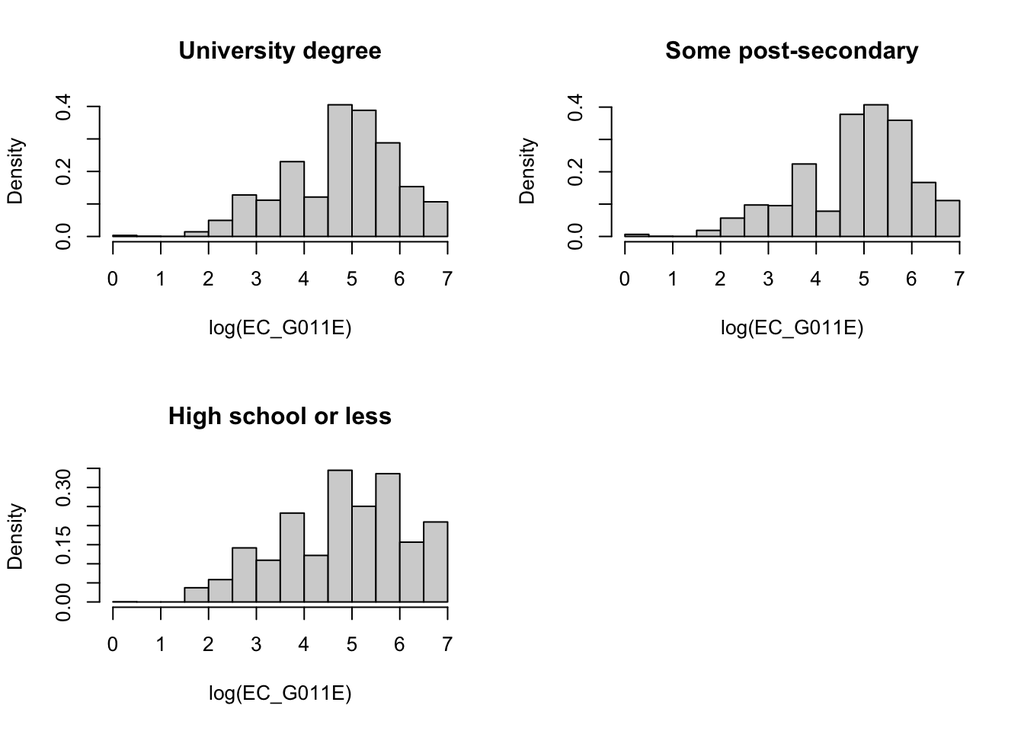

```r
# Check normality across EDU groups
par(mfrow = c(2, 2))

# Applied log to transform EC_G011E since it is highly right skewed
svyhist(~log(EC_G011E), subset(design, EDU == "University degree" & EC_G011E > 0), main = "University degree")

svyhist(~log(EC_G011E), subset(design, EDU == "Some post-secondary (incl. univ certificate)" & EC_G011E > 0), main = "Some post-secondary")

svyhist(~log(EC_G011E), subset(design, EDU == "High school or less" & EC_G011E > 0), main = "High school or less")
```

Assumption 2 of normality distribution across EDU groups is satisfied. Though there is a slight left skew but that should not be a major problem, we will live with it.

```r
# Anova model
anova_1 <- svyglm(
    formula = log(EC_G011E) ~ EDU,
    design = subset(design, EC_G011E > 0),
    na.action = na.omit
    )

survey::regTermTest(anova_1, ~EDU)  # Test if overall model is statistically significant
```

```
Wald test for EDU
 in svyglm(formula = log(EC_G011E) ~ EDU, design = subset(design,
    EC_G011E > 0), na.action = na.omit)
F =  0.8284939  on  2  and  997  df: p= 0.43701
```

```r
summary(anova_1)                    # Test if EDU levels are statistically significant
```

```
Call:
svyglm(formula = log(EC_G011E) ~ EDU, design = subset(design,
    EC_G011E > 0), na.action = na.omit)

Survey design:
subset(design, EC_G011E > 0)

Coefficients:
                                                Estimate Std. Error t value
(Intercept)                                      4.80187    0.08178  58.717
EDUSome post-secondary (incl. univ certificate)  0.04325    0.09723   0.445
EDUUniversity degree                            -0.04429    0.09176  -0.483
                                                Pr(>|t|)
(Intercept)                                       <2e-16 ***
EDUSome post-secondary (incl. univ certificate)    0.657
EDUUniversity degree                               0.629
---
Signif. codes:  0 '***' 0.001 '**' 0.01 '*' 0.05 '.' 0.1 ' ' 1

(Dispersion parameter for gaussian family taken to be 1.379444)

Number of Fisher Scoring iterations: 2
```

The F statistics and its p value 0.43 being more than 0.05 shows the model is not statistically significant and is just noise. Thus, we cannot reject the null hypothesis. The coefficients of post secondary and university are also not significant.

Therefore, among people who spent money on gaming, the model shows that the average (log) spending is equal across the three education groups.

#### H.2 **Linear Regression (single variable)**

Is there a relationship between amount spent on online gambling (EC_G011D) & amount spent on online gaming (EC_G011E) ?

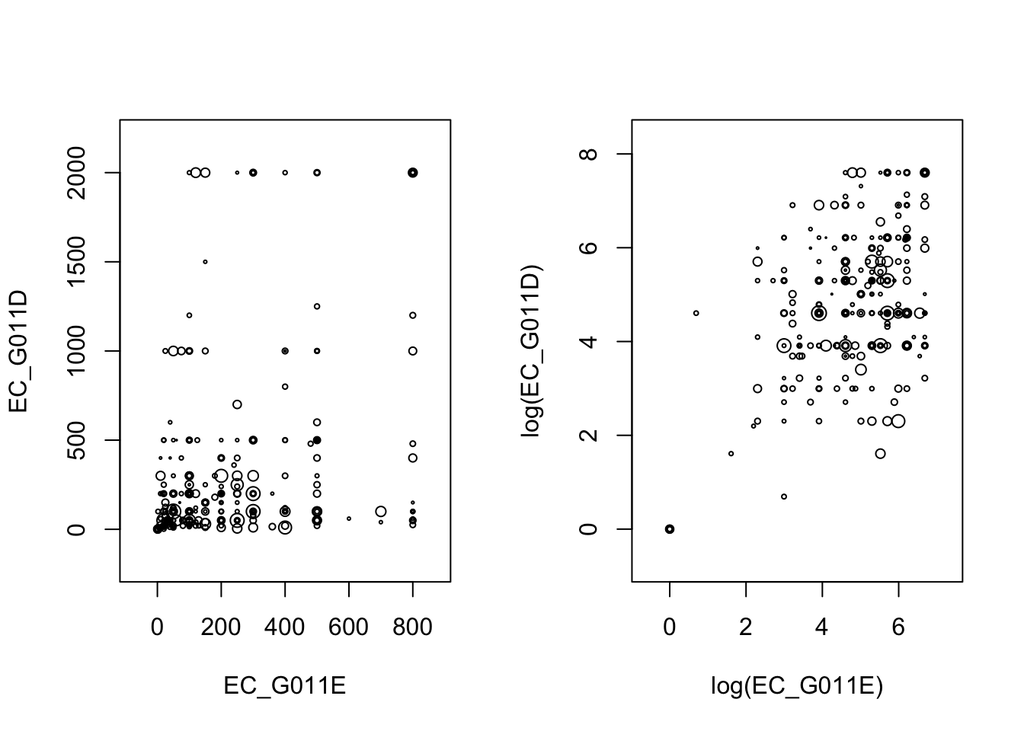

```r
# Correlation chart (filtering out zero amount spent)
par(mfrow = c(1, 2))
svyplot(~EC_G011E+EC_G011D, subset(design, EC_G011D > 0 & EC_G011E > 0))
svyplot(~log(EC_G011E) + log(EC_G011D), subset(design, EC_G011D > 0 & EC_G011E > 0))
```

The log chart shows some relationship between the two variables.

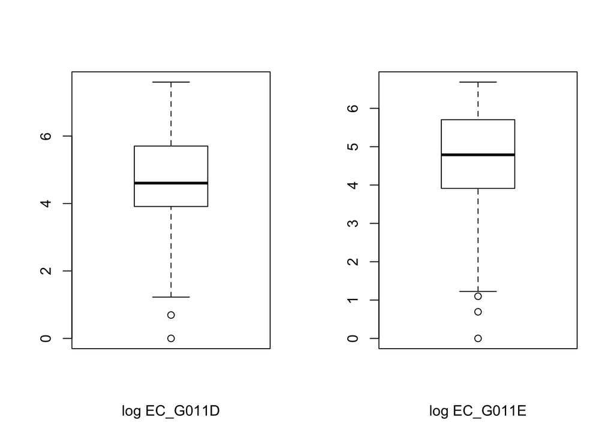

```r
par(mfrow = c(1, 2))

# Check for outliers
svyboxplot(~log(EC_G011D)~1, subset(design, EC_G011D > 0), all.outliers=TRUE, xlab = "log EC_G011D")

svyboxplot(~log(EC_G011E)~1, subset(design, EC_G011E > 0), all.outliers=TRUE, xlab = "log EC_G011E")
```

We see outliers in both the variables but we will ignore them. You may choose to remove them as well.

```r
# Linear Regression model
lm_1 <- svyglm(
    design = subset(design, EC_G011D > 0 & EC_G011E > 0),
    formula = log(EC_G011D) ~ log(EC_G011E),
    na.action = na.omit
  )

broom::tidy(lm_1)
```

| term | estimate | std.error | statistic | p.value |
| --- | --- | --- | --- | --- |
| (Intercept) | 2.3467035 | 0.48758707 | 4.812891 | 2.520404e-06 |
| log(EC_G011E) | 0.4936635 | 0.09982652 | 4.945213 | 1.363188e-06 |

This output shows that on average, for every 1% increase in spending on online gaming, there is 0.49% increase in spending on online gambling. The p value is less than 0.01 and so it is statistically significant. We can reject the null hypothesis that the slope is zero.

This model also has some assumptions to satisfy:  
1) Linearity - Dependent & independent variables must be linearly related (shown above in the chart)  
2) No influential outliers (shown above in the chart)  
3) Constant variance (homoscedasticity) - The spread of the errors is the same at every value of the predictor.  
4) Normality of errors - The errors are roughly bell-shaped.

```r
# Check for homoscedasticity & Normality of errors
par(mfrow = c(1, 2))

aug <- broom::augment(lm_1)  # Creates a data frame of the model's data
glimpse(aug)
```

```
Rows: 263
Columns: 9
$ `log(EC_G011D)` <dbl> 7.600902, 7.600902, 3.912023, 4.094345, 5.298317, 5.29…
$ `log(EC_G011E)` <dbl> 6.214608, 6.684612, 4.382027, 4.605170, 5.703782, 5.29…
$ `(weights)`     <dbl> 1.02650268, 0.84515764, 1.11530374, 0.17750643, 5.2870…
$ .fitted         <svrepstt> 5.414629, 5.646652, 4.509950, 4.620108, 5.162453,…
$ .resid          <dbl> 2.21505551, 1.79659026, -0.63145843, -0.22151202, 0.31…
$ .hat            <dbl> 0.0077861488, 0.0091375027, 0.0049444948, 0.0007126244…
$ .sigma          <dbl> 1.381349, 1.383697, 1.387661, 1.388148, 1.388077, 1.38…
$ .cooksd         <dbl> 9.921088e-03, 9.328228e-03, 4.685562e-04, 5.177242e-05…
$ .std.resid      <dbl> 1.61107584, 1.30760436, -0.45862225, -0.16054105, 0.22…
```

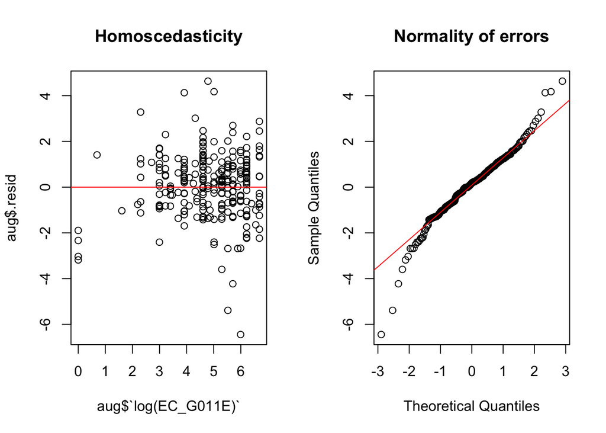

```r
plot(aug$`log(EC_G011E)`, aug$.resid, main = "Homoscedasticity")
abline(h = 0, col = "red")

# Check for Normality of errors
qqnorm(aug$.resid, main = "Normality of errors")
qqline(aug$.resid, col = "red")
```

The first chart shows homoscedasticity with errors distributed evenly and not showing a pattern. The qq plot shows residuals are normally distributed with a slight left skew. Removing the outliers would have shown a more normal distribution and no left skew. This satisfies our assumptions.

#### H.3 **Linear Regression**

Can amount spent on online gambling (EC_G011D) be better explained by amount spent on online gaming (EC_G011E) & employment ?

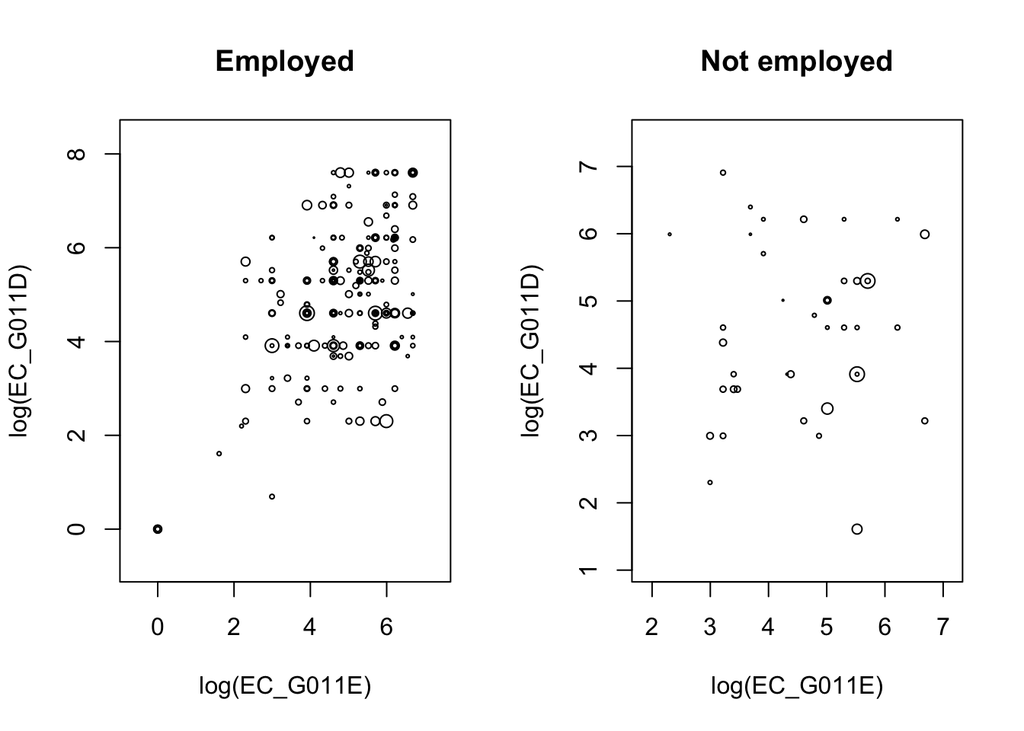

```r
# Check if there is correlation
par(mfrow = c(1, 2))

svyplot(~ log(EC_G011E) + log(EC_G011D), subset(design, EC_G011D > 0 & EC_G011E > 0 & EMP == "Employed"), main = "Employed")

svyplot(~ log(EC_G011E) + log(EC_G011D), subset(design, EC_G011D > 0 & EC_G011E > 0 & EMP == "Not employed"), main = "Not employed")
```

```r
lm_2 <- svyglm(
  design = subset(design, EC_G011D > 0 & EC_G011E > 0),
  formula = log(EC_G011D) ~ log(EC_G011E) + EMP,
  na.action = na.omit
)

broom::tidy(lm_2)
```

| term | estimate | std.error | statistic | p.value |
| --- | --- | --- | --- | --- |
| (Intercept) | 2.4486773 | 0.5308128 | 4.613071 | 6.232978e-06 |
| log(EC_G011E) | 0.4996817 | 0.1078254 | 4.634172 | 5.673669e-06 |
| EMPNot employed | -0.6055129 | 0.2996724 | -2.020583 | 4.434812e-02 |

```r
survey::regTermTest(lm_2, ~ log(EC_G011E) + EMP)   # overall model test
```

```
Wald test for log(EC_G011E) EMP
 in svyglm(design = subset(design, EC_G011D > 0 & EC_G011E > 0),
    formula = log(EC_G011D) ~ log(EC_G011E) + EMP, na.action = na.omit)
F =  12.95165  on  2  and  260  df: p= 4.3456e-06
```

This output shows that on average, for every 1% increase in spending on online gaming, there is 0.49% increase in spending on online gambling, keeping employment constant. Moreover, people who are unemployed spend 45% lower than employed people on average, keeping EC_G011E constant. The coefficient is significant at 5% alpha.

With F statistic 12.9 and its p value less than 0.01, we can reject the null hypothesis that both slopes are zero. Hence, the model is statistically significant.

```r
# Check for homoscedasticity
par(mfrow = c(1, 2))

aug_2 <- broom::augment(lm_2)  # Creates a data frame of the model's data
glimpse(aug_2)
```

```
Rows: 255
Columns: 11
$ .rownames       <chr> "1", "2", "3", "4", "5", "6", "7", "8", "9", "10", "11…
$ `log(EC_G011D)` <dbl> 7.600902, 7.600902, 3.912023, 4.094345, 5.298317, 5.29…
$ `log(EC_G011E)` <dbl> 6.214608, 6.684612, 4.382027, 4.605170, 5.703782, 5.29…
$ EMP             <fct> Employed, Employed, Not employed, Employed, Not employ…
$ `(weights)`     <dbl> 1.02650268, 0.84515764, 1.11530374, 0.17750643, 5.2870…
$ .fitted         <svrepstt> 5.554003, 5.788855, 4.032783, 4.749796, 4.693240,…
$ .resid          <dbl> 2.07384624, 1.66585954, -0.12753188, -0.27615176, 1.39…
$ .hat            <dbl> 0.0090209464, 0.0104373686, 0.0290223576, 0.0008670655…
$ .sigma          <dbl> 1.355477, 1.357732, 1.361816, 1.361729, 1.358539, 1.36…
$ .cooksd         <dbl> 7.032684e-03, 6.395116e-03, 8.202826e-05, 6.818546e-05…
$ .std.resid      <dbl> 1.54188268, 1.23943498, -0.09579022, -0.20447640, 1.11…
```

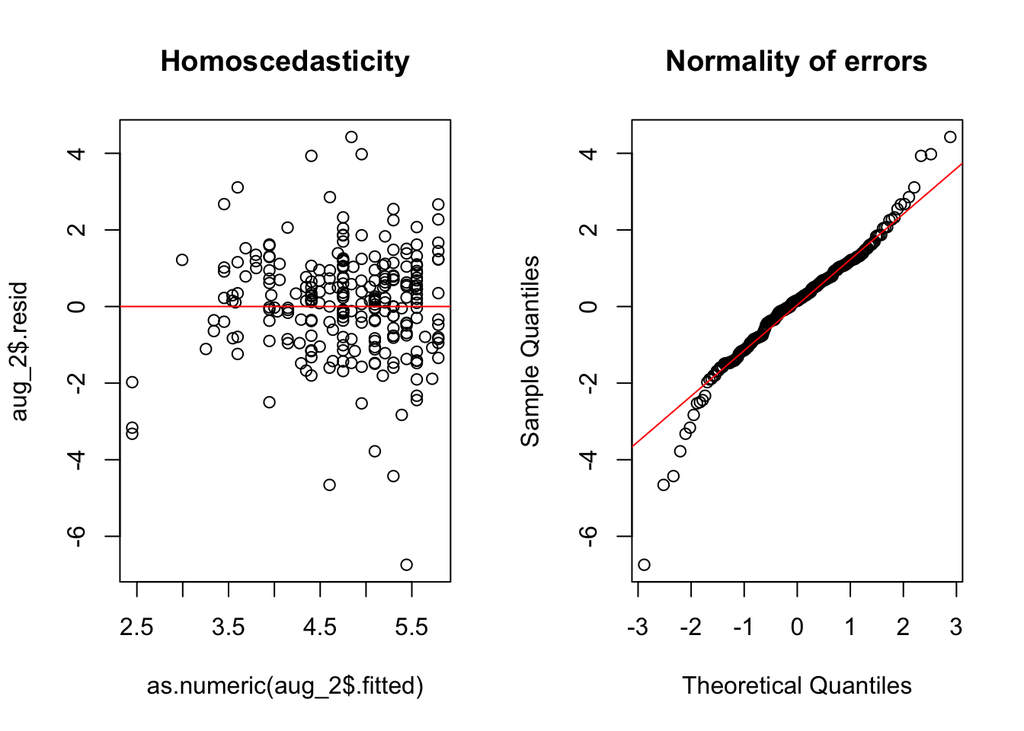

```r
plot(as.numeric(aug_2$.fitted), aug_2$.resid, main = "Homoscedasticity")
abline(h = 0, col = "red")

# Check for Normality of errors
qqnorm(aug_2$.resid, main = "Normality of errors")
qqline(aug_2$.resid, col = "red")
```

The first chart shows homoscedasticity with errors distributed evenly and not showing a pattern. The qq plot shows its normally distributed with a slight left skew. Removing the outliers would have shown a more normal distribution and no left skew. This satisfies our assumptions.

#### H.4 **Logistic Regression (single variable)**

Do non-indigenous people do more online purchase of physical goods (EC_010B) ?  
(ABM variable is for indigenous identity)

```r
logit <- design |>
  mutate(EC_010B = factor(EC_010B, levels = c("No", "Yes"))) |> # Model computes odds of 'Yes'
  svyglm(
    design = _,
    formula = EC_010B ~ ABM,
    family = quasibinomial
  )

broom::tidy(logit, exponentiate = TRUE)  # exponenent converts log odds to odds
```

| term | estimate | std.error | statistic | p.value |
| --- | --- | --- | --- | --- |
| (Intercept) | 1.614099 | 0.1313167 | 3.645973 | 0.0002801339 |
| ABMNo | 1.507728 | 0.1328918 | 3.089761 | 0.0020586464 |

(ABMNo means non-indigenous identity since ABMYes is the reference level)

The odds of buying physical goods online for non-indigenous people are 50.7% higher than indigenous people. The p value of ABMNo is less than 0.01 and so the model is statistically significant.

#### H.5 **Logistic Regression**

```r
logit <- design |>
  mutate(EC_010B = factor(EC_010B, levels = c("No", "Yes"))) |> # Model computes odds of 'Yes'
  svyglm(
    design = _,
    formula = EC_010B ~ ABM + SUM_GTOT,
    family = quasibinomial
  )

broom::tidy(logit, exponentiate = TRUE)  # exponenent converts log odds to odds
```

| term | estimate | std.error | statistic | p.value |
| --- | --- | --- | --- | --- |
| (Intercept) | 1.956216 | 2.621484e-01 | 2.559665 | 1.062385e-02 |
| ABMNo | 1.681748 | 2.626465e-01 | 1.979213 | 4.806674e-02 |
| SUM_GTOT | 1.000917 | 6.885506e-05 | 13.306009 | 2.640331e-37 |

After holding total online spending constant, non-Indigenous respondents still have about 68.2% higher odds of buying physical goods online than Indigenous respondents. Moreover, for every extra dollar spent online, the odds of buying physical goods online rise by 0.09% or 9% for every $100. Both have p values less than 0.05 and hence significant at 5% alpha.

I think those are enough examples for you to get started. This blog showed how to import, explore, setup survey design and do basic descriptive analysis, inferential analysis and modeling that uses replicate weights. This was a relatively easy survey to analyze but most of Statistics Canada surveys are similar. Now you are ready to do your own analysis.

Hope you found this helpful. Please feel free to leave your feedback on my email <matangmayur@gmail.com>

All the best!

-Mayur

Ps. Inspiration for this blog comes from [Zimmer, S. A., Powell, R. J., & Velásquez, I. C. (2024). Exploring Complex Survey Data Analysis Using R: A Tidy Introduction with {srvyr} and {survey}. Chapman & Hall: CRC Press.](https://tidy-survey-r.github.io/tidy-survey-book/index.html)